# Speech Input Corrections

# 4 Total Time

## 4.1 Chart

```r
kable(dplyr::select(data.stats.cr, inputType, taskType, mTT, sdTT))
```

| inputType | taskType | mTT | sdTT |
| --- | --- | --- | --- |
| Keyboard | Composition | 33111.55 | 15852.086 |
| Keyboard | Transcription | 19173.32 | 6895.035 |
| Speech | Composition | 29351.82 | 12751.166 |
| Speech | Transcription | 14615.00 | 5694.641 |

```r
kable(dplyr::select(data.stats.ncr, inputType, taskType, mTT, sdTT))
```

| inputType | taskType | mTT | sdTT |
| --- | --- | --- | --- |
| Keyboard | Composition | 20317.18 | 9205.792 |
| Keyboard | Transcription | 14362.28 | 5431.212 |
| Speech | Composition | 19857.60 | 10729.997 |
| Speech | Transcription | 8958.89 | 2792.521 |

## 4.2 Bar Graph

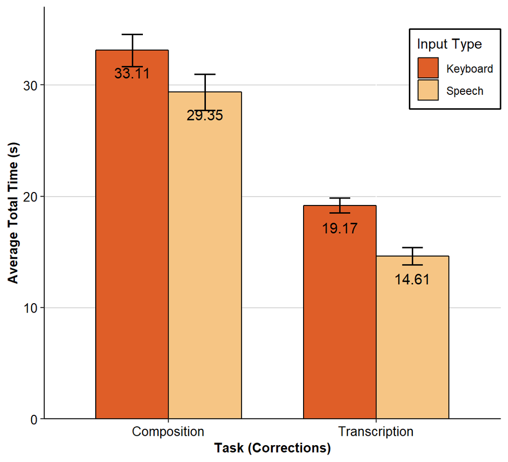

```r
createPlot(data.stats.cr, "mTT", "clTT", "cuTT", 2.5, 0.9, 0.85, "Average Total Time (s)", 0, 37, 5,x_axis="Task (Corrections)")
```

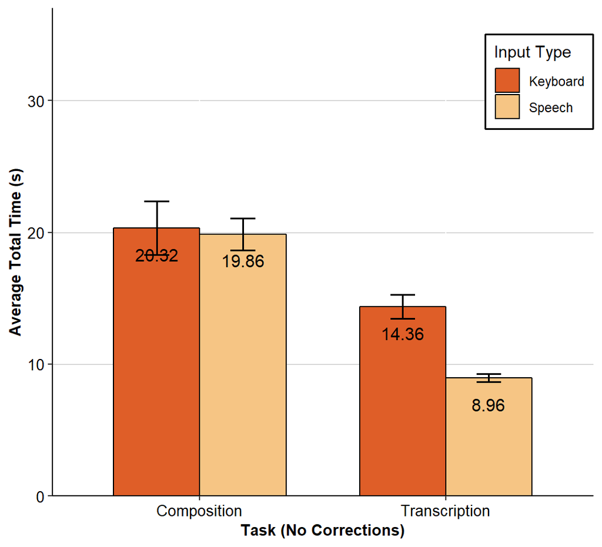

```r
createPlot(data.stats.ncr, "mTT", "clTT", "cuTT", 2.5, 0.9, 0.85, "Average Total Time (s)",0, 37, 5, x_axis="Task (No Corrections)")
```

## 4.3 Effects of Input Type and Task Type

### 4.3.1 Normality Check

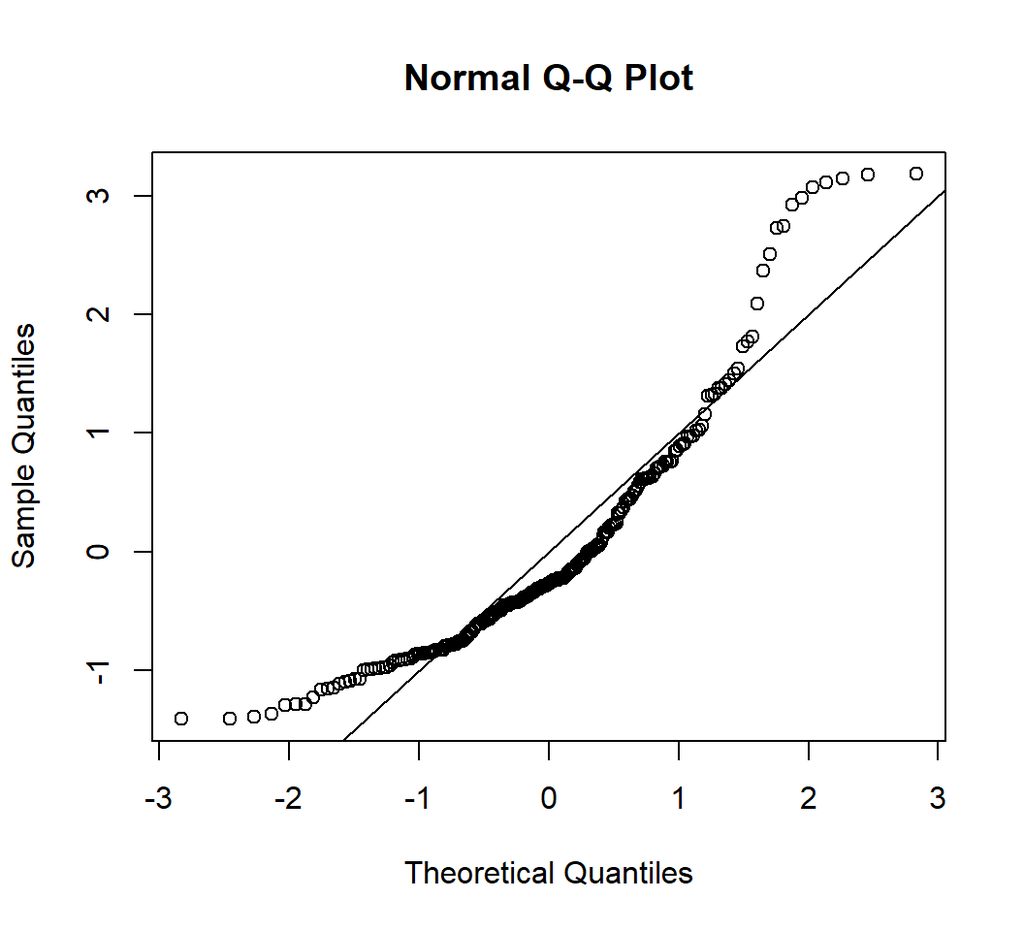

```r
m <- aov(meanTotalTime ~ hadCorrections, data=data.long)
pander(normalCheck(m))
```

Shapiro-Wilk normality test

data: res W = 0.88472, p-value = 1.013e-11

Shapiro-Wilk normality test: `res`

| Test statistic | P value |
| --- | --- |
| 0.8847 | 1.013e-11 * * * |

The data is not normally distributed.

### 4.3.2 Box-Cox Transformation

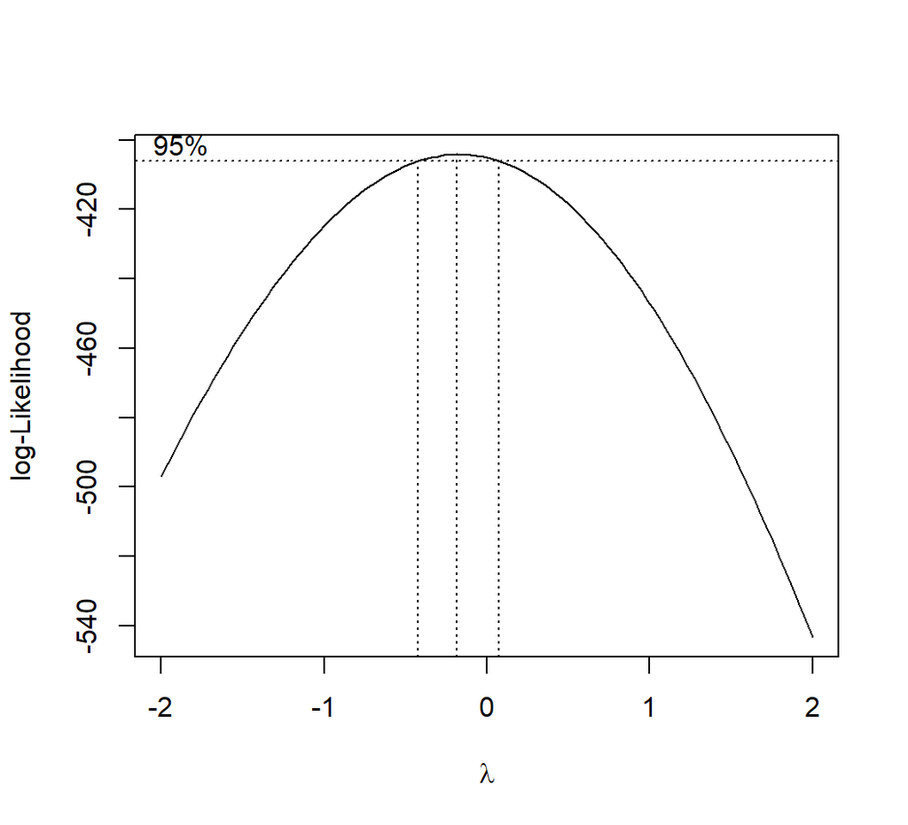

```r
boxcox(meanTotalTime ~ hadCorrections, data=data.long, plotit=T)
```

An effective lambda value is -0.25.

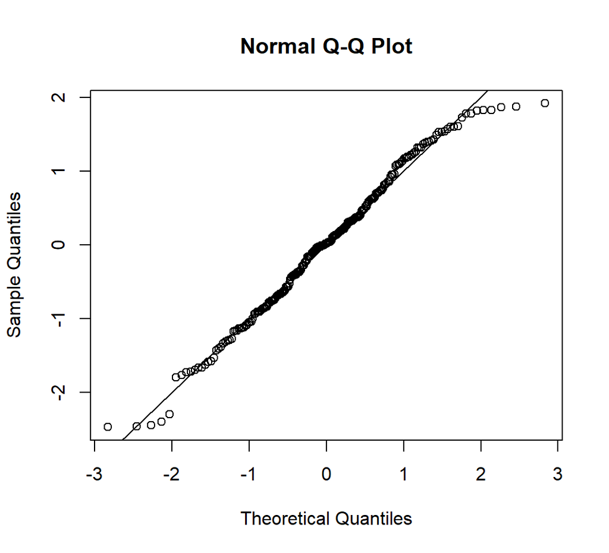

```r
datatr = data.long %>%
    mutate(meanTotalTime = meanTotalTime^(-0.25))

m <- aov(meanTotalTime ~ hadCorrections, data=datatr)
pander(normalCheck(m))
```

Shapiro-Wilk normality test

data: res W = 0.98607, p-value = 0.03395

Shapiro-Wilk normality test: `res`

| Test statistic | P value |
| --- | --- |
| 0.9861 | 0.03395 * |

### 4.3.3 Repeated measures ANOVA on transformed data

```r
anova = ezANOVA(datatr, dv=.(meanTotalTime), wid=.(participantNo), within=.(hadCorrections), detailed=TRUE)

# kable(anova$`Mauchly's Test for Sphericity`)
# kable(anova$`Sphericity Corrections`)
# kable(anova$ANOVA)
anova_apa = anova_apa(anova, sph_corr ="gg", es = "ges", print=FALSE)
input = anova_apa$text[2]
kable(anova_apa)
```

| effect | text |
| --- | --- |
| (Intercept) | F(1, 27) = 9904.48, p < .001, getasq > .99 |
| hadCorrections | F(1, 27) = 178.66, p < .001, getasq = .46 |

### 4.3.4 Post-hoc analysis with Tukey HSD

```r
t <- TukeyHSD(m)
kable(t$`hadCorrections`)
```

|  | diff | lwr | upr | p adj |
| --- | --- | --- | --- | --- |
| TRUE-FALSE | -0.0088466 | -0.0114949 | -0.0061983 | 0 |

```python
s = "There were significant main effect of corrections on Box-Cox transformed \\m{Total Time} (%s)." % (parseAnova(r.input))
writeToFile(s, "corr_totaltime.tex")
```

# 5 Words per Minute

## 5.1 Chart

```r
kable(dplyr::select(data.stats.cr, inputType, taskType, mWpm, sdWpm))
```

| inputType | taskType | mWpm | sdWpm |
| --- | --- | --- | --- |
| Keyboard | Composition | 33.66216 | 12.67883 |
| Keyboard | Transcription | 45.01430 | 12.99867 |
| Speech | Composition | 75.68120 | 47.04718 |
| Speech | Transcription | 96.63385 | 62.28302 |

```r
kable(dplyr::select(data.stats.ncr, inputType, taskType, mWpm, sdWpm))
```

| inputType | taskType | mWpm | sdWpm |
| --- | --- | --- | --- |
| Keyboard | Composition | 43.34698 | 12.94713 |
| Keyboard | Transcription | 57.03545 | 16.18425 |
| Speech | Composition | 148.93465 | 56.33706 |
| Speech | Transcription | 192.11466 | 51.56898 |

## 5.2 Bar Graph

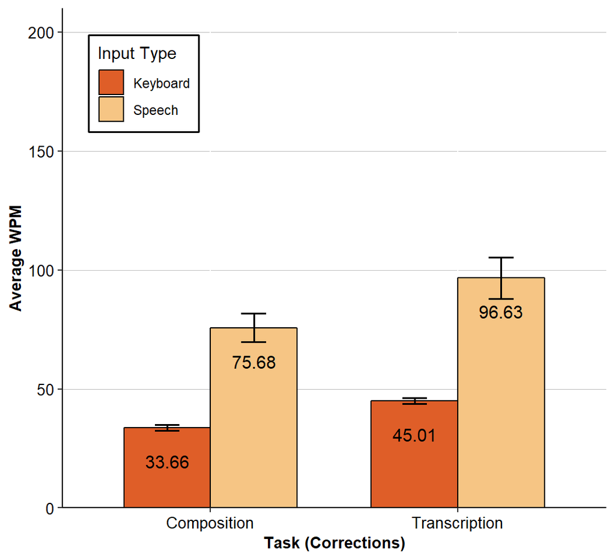

```r
createPlot(data.stats.cr, "mWpm", "clWpm", "cuWpm", 3, .15, .85, "Average WPM", 0, 210, 50, x_axis="Task (Corrections)")
```

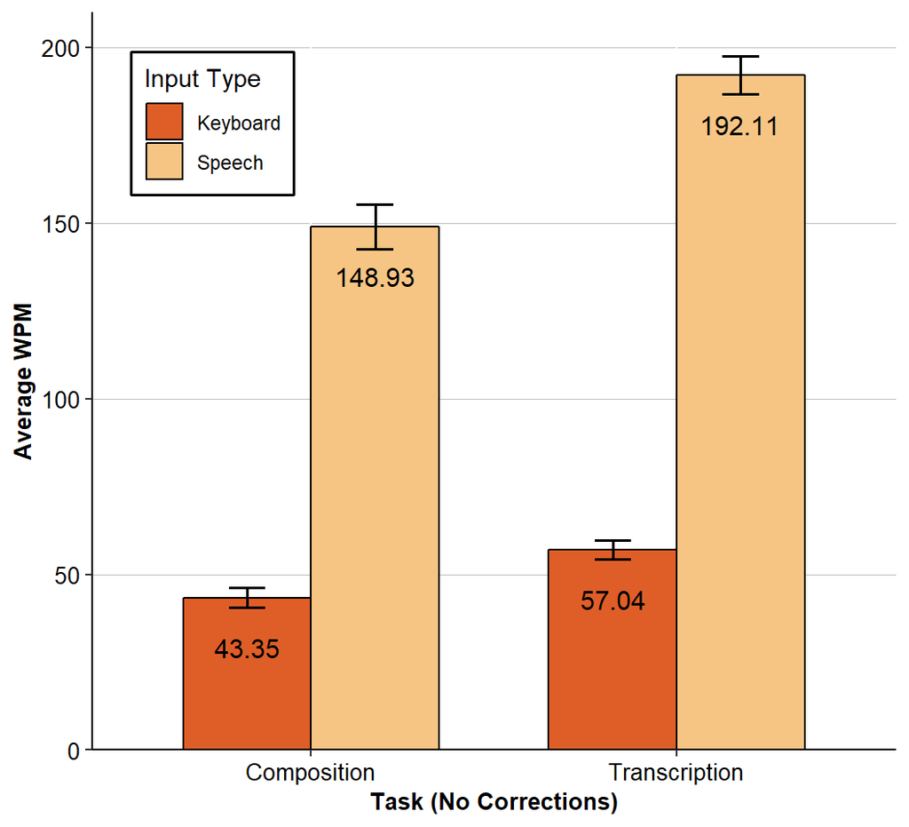

```r
createPlot(data.stats.ncr, "mWpm", "clWpm", "cuWpm", 3, .15, .85, "Average WPM", 0, 210, 50, x_axis="Task (No Corrections)")
```

## 5.3 Effects of Input Type and Task Type

### 5.3.1 Normality Check

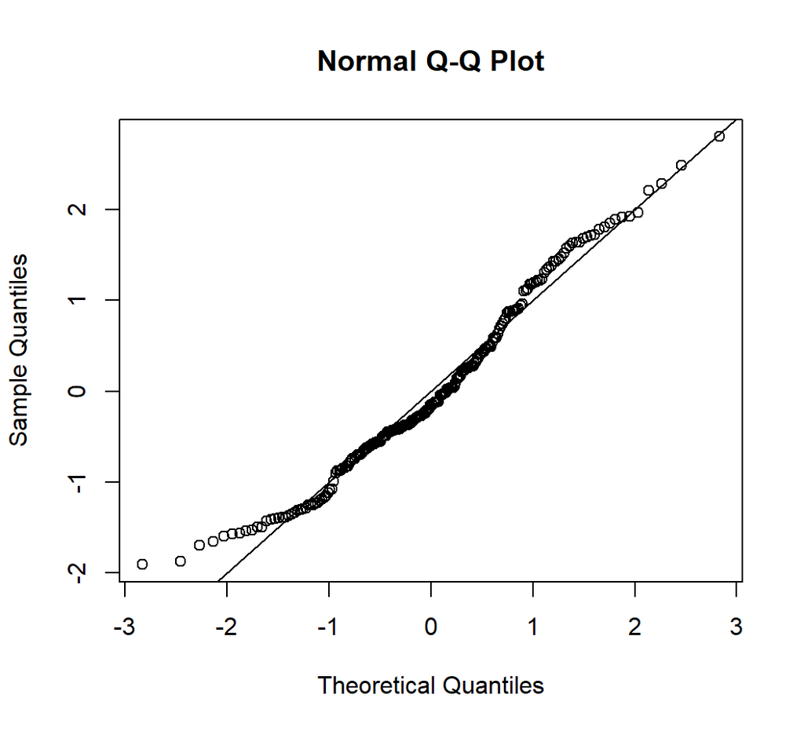

```r
m <- aov(meanWpm ~ hadCorrections, data=data.long)
pander(normalCheck(m))
```

Shapiro-Wilk normality test

data: res W = 0.97405, p-value = 0.0005538

Shapiro-Wilk normality test: `res`

| Test statistic | P value |
| --- | --- |
| 0.974 | 0.0005538 * * * |

The data is not normally distributed.

### 5.3.2 Box-Cox Transformation

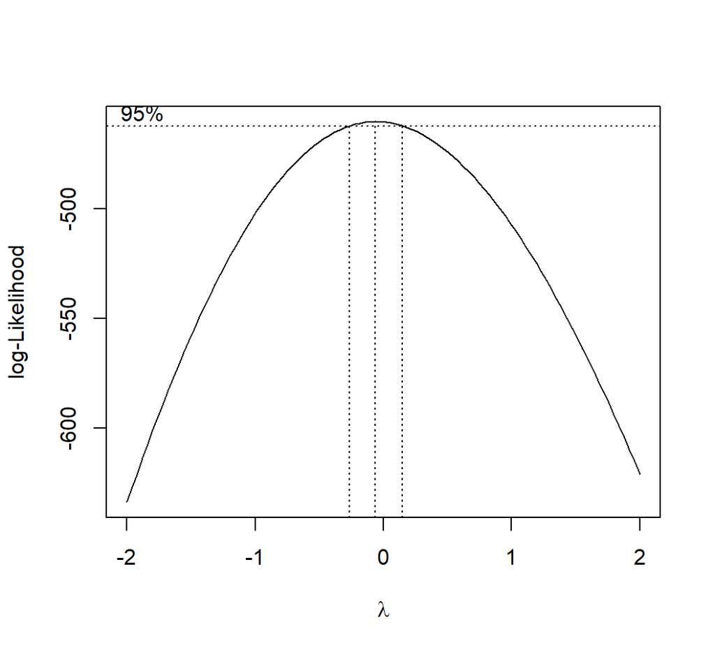

```r
boxcox(meanWpm ~ hadCorrections, data=data.long, plotit=T)
```

An effective lambda value is -0.1

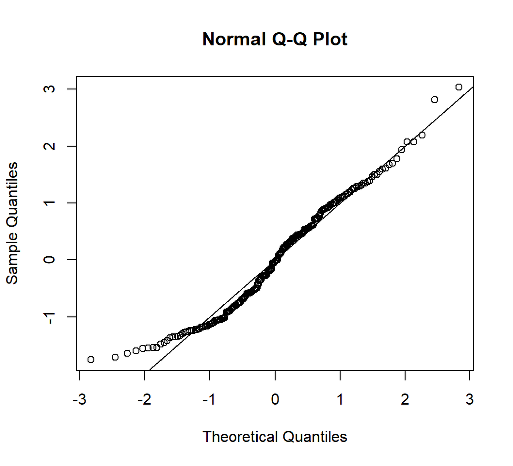

```r
datatr = data.long %>%
    mutate(meanWpm = (meanWpm)^(-0.1))

m <- aov(meanWpm ~ hadCorrections, data=datatr)
pander(normalCheck(m))
```

Shapiro-Wilk normality test

data: res W = 0.96878, p-value = 0.0001129

Shapiro-Wilk normality test: `res`

| Test statistic | P value |
| --- | --- |
| 0.9688 | 0.0001129 * * * |

### 5.3.3 Repeated measures ANOVA on transformed data

```r
anova = ezANOVA(datatr, dv=.(meanWpm), wid=.(participantNo), within=.(hadCorrections), detailed=TRUE)

anova_apa = anova_apa(anova, sph_corr ="gg", es = "ges", print=FALSE)
input = anova_apa$text[2]
kable(anova_apa)
```

| effect | text |
| --- | --- |
| (Intercept) | F(1, 27) = 78202.55, p < .001, getasq > .99 |
| hadCorrections | F(1, 27) = 159.78, p < .001, getasq = .63 |

```python
s = "There was a significant main effect of corrections on Box-Cox transformed \\m{WPM} (%s)." % (parseAnova(r.input))
writeToFile(s, "corr_wpm.tex")
```

### 5.3.4 Post-hoc analysis with Tukey HSD

```r
t <- TukeyHSD(m)
kable(t$`hadCorrections`)
```

|  | diff | lwr | upr | p adj |
| --- | --- | --- | --- | --- |
| TRUE-FALSE | 0.035149 | 0.0247615 | 0.0455364 | 0 |

# 6 Uncorrected Error Rate

## 6.1 Chart

```r
kable(dplyr::select(data.stats.cr, inputType, taskType, m_uer, sd_uer))
```

| inputType | taskType | m_uer | sd_uer |
| --- | --- | --- | --- |
| Keyboard | Composition | 0.0050527 | 0.0128450 |
| Keyboard | Transcription | 0.0033234 | 0.0142148 |
| Speech | Composition | 0.0088115 | 0.0240289 |
| Speech | Transcription | 0.0133879 | 0.0296728 |

```r
kable(dplyr::select(data.stats.ncr, inputType, taskType, m_uer, sd_uer))
```

| inputType | taskType | m_uer | sd_uer |
| --- | --- | --- | --- |
| Keyboard | Composition | 0.0030662 | 0.0107090 |
| Keyboard | Transcription | 0.0037394 | 0.0120633 |
| Speech | Composition | 0.0053845 | 0.0162024 |
| Speech | Transcription | 0.0061681 | 0.0213559 |

## 6.2 Bar Graph

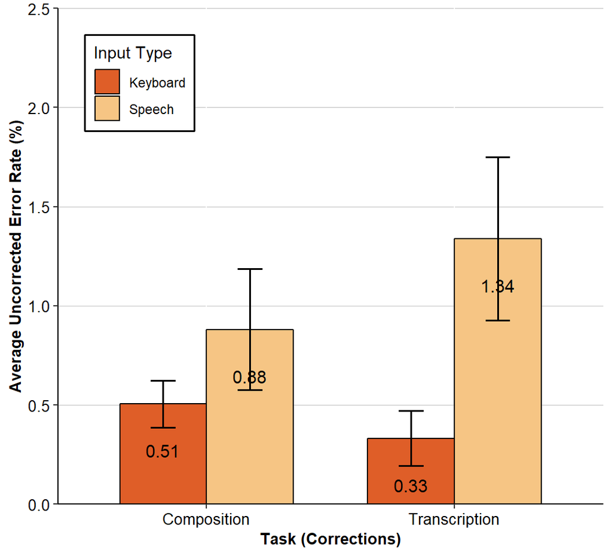

```r
createPlot(data.stats.cr, "m_uer", "cl_uer", "cu_uer", 4, 0.15, 0.85, "Average Uncorrected Error Rate (%)", 0, 2.5, 0.3, x_axis = "Task (Corrections)")
```

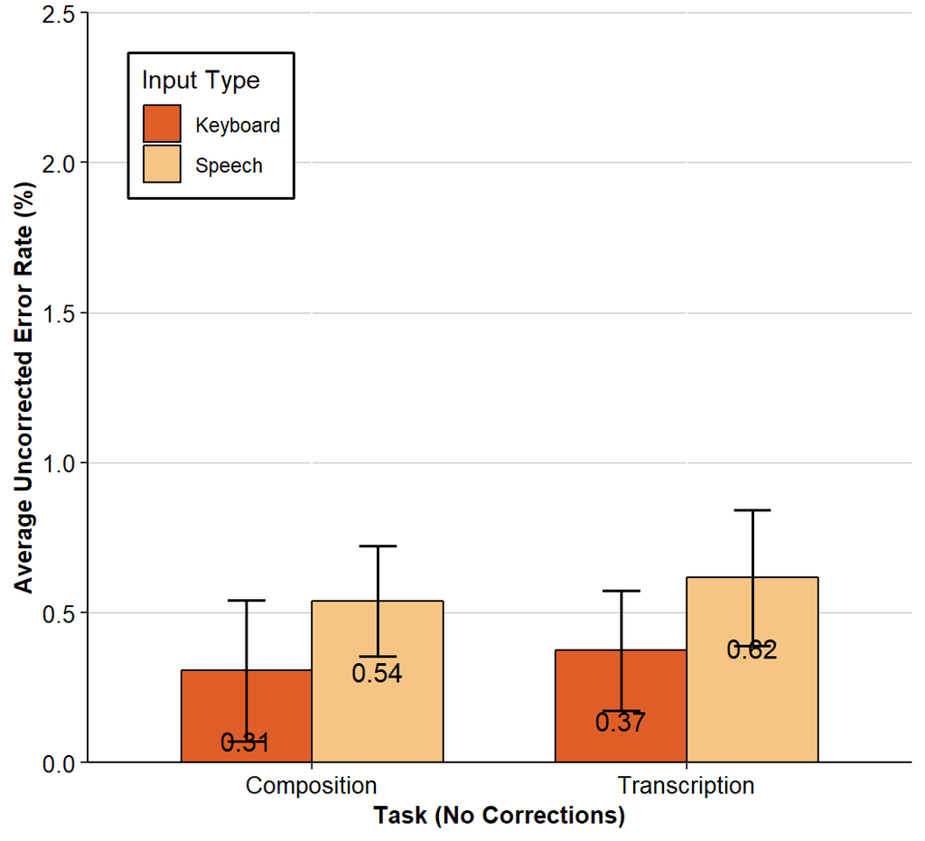

```r
createPlot(data.stats.ncr, "m_uer", "cl_uer", "cu_uer", 4, 0.15, 0.85, "Average Uncorrected Error Rate (%)", 0, 2.5, 0.3, x_axis = "Task (No Corrections)")
```

## 6.3 Effects of Input Type and Task Type

### 6.3.1 Normality Check

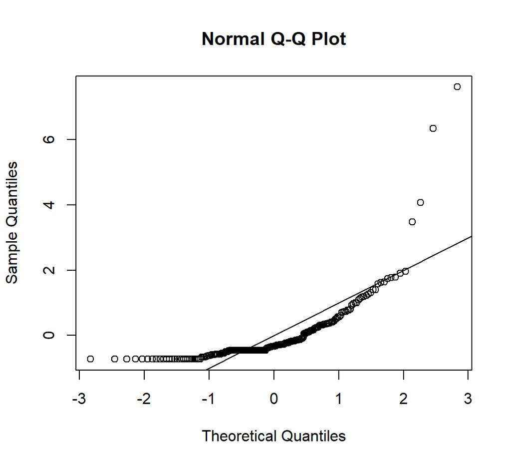

```r
m <- aov(mean_uer ~ hadCorrections, data=data.long)
pander(normalCheck(m))
```

Shapiro-Wilk normality test

data: res W = 0.62122, p-value < 2.2e-16

Shapiro-Wilk normality test: `res`

| Test statistic | P value |
| --- | --- |
| 0.6212 | 1.687e-21 * * * |

The data is not normally distributed.

### 6.3.2 ANOVAs in ART Data

```r
a = art(mean_uer ~ hadCorrections + (1|participantNo), data=data.long)
anova(a)
```

```
## Analysis of Variance of Aligned Rank Transformed Data
##
## Table Type: Analysis of Deviance Table (Type III Wald F tests with Kenward-Roger df)
## Model: Mixed Effects (lmer)
## Response: art(mean_uer)
##
##                       F Df Df.res    Pr(>F)
## 1 hadCorrections 8.6406  1 185.96 0.0037045 **
## ---
## Signif. codes:   0 '***' 0.001 '**' 0.01 '*' 0.05 '.' 0.1 ' ' 1
```

### 6.3.3 Post-hoc Corrections

```r
emmeans(artlm(a, "hadCorrections"), pairwise ~ hadCorrections)
```

```
## $emmeans
##  hadCorrections    emmean       SE    df  lower.CL upper.CL
##  FALSE           96.47547 7.607651 46.87  81.16976 111.7812
##  TRUE           117.69643 7.426422 43.07 102.72036 132.6725
##
## Degrees-of-freedom method: kenward-roger
## Confidence level used: 0.95
##
## $contrasts
##  contrast      estimate       SE     df t.ratio p.value
##  FALSE - TRUE -21.22096 7.219267 185.96  -2.939  0.0037
```